# KidSearch Analyses:

## GitHub Documents

Code to reproduce the analyses in manuscript, “Animacy and object size are reflected in preschoolers perceptual similarity computations by the preschool years”

## Step 1: Load data and choose experiment

```r
#
library(readxl) # import excel files
library(tidyverse) # for data munging

e1 = read_tsv("data/Animacy.txt")
e2 = read_tsv("data/ObjectSize.txt")

## Choose experiment!
exp = e1
expName = 'Animacy'

#exp = e2
#expName = 'Size'
```

## Step 2: Load most packages

```r
library(knitr) # for kable table formating
library(forcats) #manipulating factors in data frames
library(ez) # for anova
library(lme4)
library(ggthemes)
library(ggplot2)
library(langcog) #multi_boot_standard function for bootstrapping CIs
library(lmerTest)
```

## Step 3: Preprocess data

```r
##
exp$subject = as.factor(exp$sub)
exp$conditionNum = as.numeric(exp$condition)
exp$conditionName = as.factor(exp$conditionName)
exp$categoryNum = as.numeric(exp$categoryNum)
exp$category = as.factor(exp$category)

## Step 3: Preprocess data
# count how many trials per subject
trialCount=exp %>%
  dplyr::group_by(subject) %>%
  summarise(trials=sum(phase=='SixItems'), correctTrials=sum(correct==1 & phase=='SixItems'), errors=sum(correct==0 & phase=='SixItems'), slow=sum(RT>4000 & phase=='SixItems' & correct==1))

# what percentage of all trials were incorrect?
round(mean(trialCount$errors/trialCount$trials)*100,2)
```

```
## [1] 16.14
```

```r
# what percentage of correct trials were slow?
round(mean(trialCount$slow/trialCount$correctTrials)*100,2)
```

```
## [1] 6.36
```

```r
# Only get data with correct trials less than 4 seconds long when there were six items on the screen.
exp.tidy=exp %>%
  filter(RT<4000) %>%
  filter(correct==1) %>%
  filter(phase=='SixItems')

# also construct dataset without RT trimming
exp.tidy.notrim=exp %>%
  filter(RT<10000) %>%
  filter(correct==1) %>%
  filter(phase=='SixItems')

# make log RT
exp.tidy$logRT=log(exp.tidy$RT);

# Now only include subjects who had more than 1 trial speeded trial in each of 4 conditions
exp.tidy=exp.tidy %>%
  dplyr::group_by(subject) %>%
  mutate(indivCountC1=sum(conditionNum==1 & categoryNum==1)) %>%
  mutate(indivCountC2=sum(conditionNum==1 & categoryNum==2)) %>%
  mutate(indivCountC3=sum(conditionNum==2 & categoryNum==1)) %>%
  mutate(indivCountC4=sum(conditionNum==2 & categoryNum==2)) %>%
  filter(indivCountC1>1) %>%
  filter(indivCountC2>1) %>%
  filter(indivCountC3>1) %>%
  filter(indivCountC4>1)

# for both versions of dataset
exp.tidy.notrim=exp.tidy.notrim %>%
  dplyr::group_by(subject) %>%
  mutate(indivCountC1=sum(conditionNum==1 & categoryNum==1)) %>%
  mutate(indivCountC2=sum(conditionNum==1 & categoryNum==2)) %>%
  mutate(indivCountC3=sum(conditionNum==2 & categoryNum==1)) %>%
  mutate(indivCountC4=sum(conditionNum==2 & categoryNum==2)) %>%
  filter(indivCountC1>1) %>%
  filter(indivCountC2>1) %>%
  filter(indivCountC3>1) %>%
  filter(indivCountC4>1)

# Store included subs
includedSubs=unique(exp.tidy$subject)

# How many trials are included in each condition in this subset of children?
trialCountIncludedSubs=exp.tidy %>%
  dplyr::group_by(subject) %>%
  filter(is.element(subject,includedSubs)) %>%
  dplyr::summarise(trialCount=length(RT), uniformCount=sum(conditionNum==1), mixedCount=sum(conditionNum==2))

# overall how many trials (and sd)
round(mean(trialCountIncludedSubs$trialCount),2)
```

```
## [1] 27.07
```

```r
round(sd(trialCountIncludedSubs$trialCount),2)
```

```
## [1] 12.35
```

```r
# how many trials on average per condition?
round(mean(trialCountIncludedSubs$uniformCount),2)
```

```
## [1] 13.5
```

```r
round(mean(trialCountIncludedSubs$mixedCount),2)
```

```
## [1] 13.57
```

```r
# Compute accuracy means
exp.accuracy <- exp %>%
  dplyr::group_by(subject,conditionName, category) %>%
  filter(phase=='SixItems') %>%
  filter(is.element(subject,includedSubs)) %>% # only use subs included in RT anlayses for consistency
  dplyr::summarise(meanAcc = mean(correct)) # average wtihin subjects
```

## Step 4: Accuracy results

```r
# summarize accuracy results
condAccMeans=exp.accuracy %>%
  dplyr::group_by(conditionName) %>%
  dplyr::summarize(avgCondAcc=mean(meanAcc), sdCondRT=sd(meanAcc))

categAccMeans=exp.accuracy %>%
  dplyr::group_by(category) %>%
  dplyr::summarize(avgCondAcc=mean(meanAcc), sdCondRT=sd(meanAcc))

# descriptive means (mixed v uniform)
UniMixAcc=round(condAccMeans$avgCondAcc*100,2)
CategoryAccs=round(categAccMeans$avgCondAcc*100,2)

# ANOVA
accuracyResults=ezANOVA(dv= .(meanAcc), wid= .(subject), within= .(conditionName, category), detailed=TRUE, data=data.frame(exp.accuracy), type=3)
partialEtaSquared=accuracyResults$ANOVA$SSn/(accuracyResults$ANOVA$SSn + accuracyResults$ANOVA$SSd)
```

Children were 84.97% accurate on mixed trials, and 86.3% on uniform category trials.

Children were 83.68% accurate on Animals trials, and 87.59% on Objects trials.

Effect of condition on accuracy: (*F*(1,13)= 0.21, *p* = 0.65, *partial eta squared*= 0.02

Effect of category on accuracy: (*F*(1,13)= 2.19, *p* = 0.16, *partial eta squared*= 0.14

Effect of their interaction on accuracy: (*F*(1,13)= 1.6, *p* = 0.23, *partial eta squared*= 0.11

## Step 5: RT results

```r
## Calculate descriptive statistics: Means and SD
avgByCondAndCat=exp.tidy %>%
  dplyr::group_by(conditionName,category,subject) %>%
  dplyr::summarise(meanRT= mean(RT))

avgByCondAndCatLog=exp.tidy %>%
  dplyr::group_by(conditionName,category,subject) %>%
  dplyr::summarise(medLog = median(logRT))

# Report descriptives
condMeans=avgByCondAndCat %>%
  dplyr::group_by(conditionName) %>%
  dplyr::summarize(avgCondRT=mean(meanRT), sdCondRT=sd(meanRT))

UniMixRT=round(condMeans$avgCondRT,0)
UniMixRT_SDs=round(condMeans$sdCondRT,0)

# now by category
categoryMeans=avgByCondAndCat %>%
  dplyr::group_by(category) %>%
  dplyr::summarize(avgCatRT=mean(meanRT), sdCatRT=sd(meanRT))

# output category means
CategoryRT=round(categoryMeans$avgCatRT,0)
Category_SDs=round(categoryMeans$sdCatRT,0)

## Inferential statistics: ANOVA
RTResults=ezANOVA(dv= .(RT), wid= .(subject), within= .(conditionName, category), detailed=TRUE, data=data.frame(exp.tidy), type=3)
partialEtaSquaredRT=RTResults$ANOVA$SSn/(RTResults$ANOVA$SSn + RTResults$ANOVA$SSd)

RTResults_NoTrim=ezANOVA(dv= .(RT), wid= .(subject), within= .(conditionName, category), detailed=TRUE, data=data.frame(exp.tidy.notrim), type=3)
partialEtaSquaredRT=RTResults$ANOVA$SSn/(RTResults$ANOVA$SSn + RTResults$ANOVA$SSd)

# ezDesign(exp.tidy, x = RT, y = subject, row = conditionName, col = category)

## with log RT? Check to be sure this is the same.
RTResults_Log=ezANOVA(dv= .(logRT), wid= .(subject), within= .(conditionName, category), detailed=TRUE, data=data.frame(exp.tidy), type=3)
partialEtaSquaredRT=RTResults$ANOVA$SSn/(RTResults$ANOVA$SSn + RTResults$ANOVA$SSd)

## Cohens DZ calculation
avgByCond=exp.tidy %>%
  dplyr::group_by(conditionName,subject) %>%
  dplyr::summarise(meanRT= mean(RT))

effectBySub=avgByCond$meanRT[avgByCond$conditionName=='uniform']-avgByCond$meanRT[avgByCond$conditionName=='mixed']
dz=mean(effectBySub)/sd(effectBySub)
```

### Output table of RT results

```r
kable(RTResults)
```

| Effect | DFn | DFd | SSn | SSd | F | p | p<.05 | ges |
| --- | --- | --- | --- | --- | --- | --- | --- | --- |
| (Intercept) | 1 | 13 | 173588832.29 | 4083999.5 | 552.560012 | 0.0000000 | * | 0.9668352 |
| conditionName | 1 | 13 | 1487220.75 | 421399.6 | 45.880133 | 0.0000131 | * | 0.1998483 |
| category | 1 | 13 | 47570.35 | 571566.0 | 1.081965 | 0.3172182 |  | 0.0079256 |
| conditionName:category | 1 | 13 | 121456.49 | 877562.4 | 1.799227 | 0.2027700 |  | 0.0199896 |

### Output table of RT results without trimming

```r
kable(RTResults_NoTrim)
```

| Effect | DFn | DFd | SSn | SSd | F | p | p<.05 | ges |
| --- | --- | --- | --- | --- | --- | --- | --- | --- |
| (Intercept) | 1 | 13 | 213399258.18 | 11526822 | 240.6726107 | 0.0000000 | * | 0.9234044 |
| conditionName | 1 | 13 | 3858128.97 | 1806115 | 27.7699174 | 0.0001516 | * | 0.1789534 |
| category | 1 | 13 | 91437.19 | 2254598 | 0.5272263 | 0.4806448 |  | 0.0051390 |
| conditionName:category | 1 | 13 | 359651.86 | 2113745 | 2.2119385 | 0.1607953 |  | 0.0199132 |

```r
if (expName=="Animacy"){
  fewerSubs=8 # half
}

if (expName=="Size") {
  fewerSubs=16  # size of exp 1
}

dz_splitHalf = array()
condEffect_splitHalf = array()
sig_out = array()
for (iter in 1:1000){
  theseSubs = sample(unique(exp.tidy$sub),fewerSubs)
  avgByCond_Split <- avgByCond %>%
    filter(is.element(subject,theseSubs))
  temp=avgByCond_Split$meanRT[avgByCond_Split$conditionName=='uniform']-avgByCond_Split$meanRT[avgByCond_Split$conditionName=='mixed']
  dz_splitHalf[iter]=mean(temp)/sd(temp)
  condEffect_splitHalf[iter]=mean(temp)
  out = t.test(temp)
  p_val = out[3]$p.value
  sig_out[iter]=p_val
}

# how often would we have found an effect in these samples?
# sum(sig_out<.05)/5
```

### Make plot (Figure 2)

```r
plotSummary<- exp.tidy %>%
  group_by(subject,category,conditionName) %>%
  dplyr::summarize(meanRT = mean(RT)) %>%
  group_by(category,conditionName) %>%
  multi_boot_standard(col = "meanRT")


if (expName=="Animacy"){
  levels(plotSummary$category) = c("Animal Targets","Inanimate Targets")
  levels(plotSummary$conditionName) = c("Uniform Animacy","Mixed Animacy")
  relevel(plotSummary$conditionName,ref="Uniform Animacy")}
```

```
## [1] Uniform Animacy Mixed Animacy   Uniform Animacy Mixed Animacy
## Levels: Uniform Animacy Mixed Animacy
```

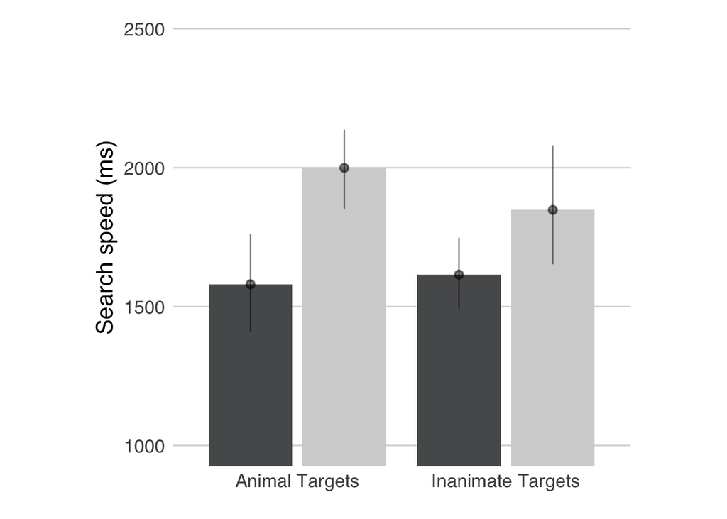

```r
if (expName=="Size"){
  levels(plotSummary$category) = c("Big Object \n Targets","Small Object \n Targets")
  levels(plotSummary$conditionName) = c("Uniform Size","Mixed Size")
  relevel(plotSummary$conditionName,ref="Uniform Size")}


# Make plot
plotLimits=c(1000,2500)
dodge <- position_dodge(width = 0.9)
(plot_out = ggplot(plotSummary, aes(x=category,y=mean, fill=conditionName)) +
  geom_bar(stat="identity", position=dodge, width=.8) +  # plot the point
  geom_pointrange(aes(ymin=ci_lower, ymax=ci_upper), width=.1, position=dodge, alpha=.5) +
  coord_cartesian(ylim=plotLimits) + # ugh, need this for some reason with bar plots
  theme_hc(base_size=16)  + ## change ggplot theme, number here modulates size of text
  theme(axis.ticks.x=element_blank(),   axis.ticks.y=element_blank()) +
  scale_fill_manual(values = c("#58595B","#D3D3D3"), guide="legend")+
  theme(text=element_text(family="Helvetica")) +
  theme(aspect.ratio=1) +
  labs(x="", y="Search speed (ms)") + # kill redudant x label +
  # ggtitle("Mean RT by Condition & Category") +
  theme(legend.title = element_blank(),
           legend.justification=c(0,1),
           legend.position=c(0, 1.2),
           legend.background = element_blank(),
           legend.key = element_blank()))
```

```r
ggsave(paste0('Figure2_', expName, '.pdf'), width = 4, height = 5,unit =  "in", plot = plot_out, path="figures", device = "pdf",dpi = 300)
```

Children took 1598ms on mixed category trials, and 1924ms on uniform category trials.

Children took 1790ms on Animals trials, and 1731ms on Objects trials.

Effect of condition on RT: (*F*(1,13)= 45.88, *p* = 0, *partial eta squared*= 0.78

Effect of category on RT: (*F*(1,13) = 1.08, *p* = 0.32, *partial eta squared*= 0.08

Effect of their interaction on RT: (*F*(1,13) = 1.8, *p* = 0.2, *partial eta squared*= 0.12

Cohens DZ for condition of interest (uniform vs. mixed): Cohens *dz* = 1.57

We found the same pattern of effects when we included trials slower than 4 seconds (still excluding trials with RTs>10 seconds, *F*(1,13)= 27.77, *p* = 0

## Step 6: Mixed effect models

```r
##Inferential statistics: Mixed-effects models
# Note: no effect modeled of condition on targetItems; model fails to converge.

# Fixed effects of category and condition, and random effects of subjects and target items on the intercept,
mainModel.report <- lmer(log(RT) ~ category*conditionName + (1|sub) + (1|targetItem), data=exp.tidy, REML=TRUE)
mainModel.compare <- lmer(log(RT) ~ category*conditionName + (1|sub) + (1|targetItem), data=exp.tidy, REML=FALSE)

# null model - no fixed factor of condition or it's interaction (i.e., uniform/mixed), same random effects structure as exp.MainModel
nullModel<- lmer(log(RT) ~ category + (1|sub) + (1|targetItem), data=exp.tidy, REML=FALSE)

# Essential model comparison
anova(mainModel.compare, nullModel)
```

```
## Data: exp.tidy
## Models:
## ..1: log(RT) ~ category + (1 | sub) + (1 | targetItem)
## object: log(RT) ~ category * conditionName + (1 | sub) + (1 | targetItem)
##        Df    AIC    BIC  logLik deviance  Chisq Chi Df Pr(>Chisq)
## ..1     5 300.56 320.24 -145.28   290.56
## object  7 280.47 308.03 -133.23   266.47 24.087      2  5.882e-06 ***
## ---
## Signif. codes:  0 '***' 0.001 '**' 0.01 '*' 0.05 '.' 0.1 ' ' 1
```

```r
model_out = summary(mainModel.report)
kable(summary(mainModel.report)$coef)
```

|  | Estimate | Std. Error | df | t value | Pr(>\|t\|) |
| --- | --- | --- | --- | --- | --- |
| (Intercept) | 7.3297157 | 0.0495709 | 30.10937 | 147.8633157 | 0.0000000 |
| categoryObjects | 0.0043959 | 0.0489390 | 360.20882 | 0.0898241 | 0.9284769 |
| conditionNameuniform | 0.2224823 | 0.0494328 | 358.18345 | 4.5007029 | 0.0000092 |
| categoryObjects:conditionNameuniform | -0.1200824 | 0.0693714 | 359.75188 | -1.7310073 | 0.0843079 |

This result was confired using linear mixed-effect models (B = 0.22, SE = 0.05, t = 4.5, p = 0)

## Reviewer questions:

### (1) Is there a relationship between number of trials completed by each child and overall accuracy?

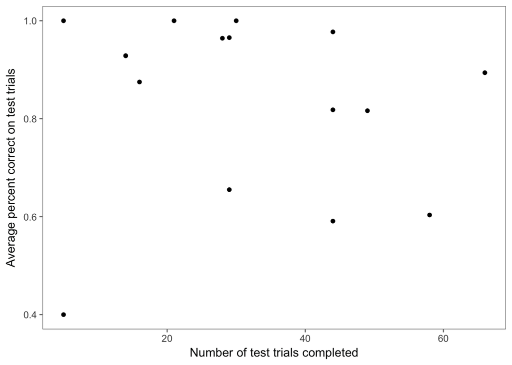

```r
trialCount <- trialCount %>%
  mutate(avg_correct = correctTrials / trials)

# plot it
ggplot(trialCount, aes(x=trials, y=avg_correct)) +
  geom_point() +
  xlab('Number of test trials completed') +
  ylab('Average percent correct on test trials') +
  theme_few()
```

```r
# Were children who compeleted more trials likely to be more acccurate?
trials_by_overall_acc = cor.test(trialCount$trials, trialCount$avg_correct)
kable(trialCount)
```

| subject | trials | correctTrials | errors | slow | avg_correct |
| --- | --- | --- | --- | --- | --- |
| 1 | 66 | 59 | 7 | 4 | 0.8939394 |
| 2 | 44 | 26 | 18 | 1 | 0.5909091 |
| 3 | 58 | 35 | 23 | 7 | 0.6034483 |
| 4 | 14 | 13 | 1 | 1 | 0.9285714 |
| 5 | 5 | 2 | 3 | 0 | 0.4000000 |
| 6 | 29 | 19 | 10 | 3 | 0.6551724 |
| 7 | 21 | 21 | 0 | 0 | 1.0000000 |
| 8 | 14 | 13 | 1 | 0 | 0.9285714 |
| 9 | 28 | 27 | 1 | 2 | 0.9642857 |
| 10 | 30 | 30 | 0 | 0 | 1.0000000 |
| 11 | 29 | 28 | 1 | 1 | 0.9655172 |
| 12 | 49 | 40 | 9 | 0 | 0.8163265 |
| 13 | 44 | 43 | 1 | 0 | 0.9772727 |
| 14 | 16 | 14 | 2 | 0 | 0.8750000 |
| 15 | 5 | 5 | 0 | 1 | 1.0000000 |
| 16 | 44 | 36 | 8 | 6 | 0.8181818 |

### (2) Do children who complete more trials show a greater mixed-effect accuracy benefit?

[figure not shown]

```r
trials_by_acc_effect<- exp %>%
  dplyr::group_by(subject,conditionName) %>%
  filter(phase=='SixItems') %>%
  filter(is.element(subject,includedSubs)) %>% # only use subs included in RT anlayses for consistency
  summarize(trial_count = n(), condition_acc = mean(correct)) %>%
  summarize(trial_count_total = trial_count[conditionName=="mixed"] + trial_count[conditionName=="uniform"], cong_effect = condition_acc[conditionName=="mixed"] - condition_acc[conditionName=="uniform"])

ggplot(trials_by_acc_effect, aes(x=trial_count_total, y=cong_effect)) +
  geom_point() +
  xlab('Number of test trials completed') +
  ylab('Congruency RT effect') +
  theme_few()
```

```r
# Were children who compeleted more trials likely to show a congruency accuracy effect?
trials_by_acc_cong = cor.test(trials_by_acc_effect$trial_count_total, trials_by_acc_effect$cong_effect)
```

### (3) Do children who complete more trials show a greater mixed-effect RT benefit?

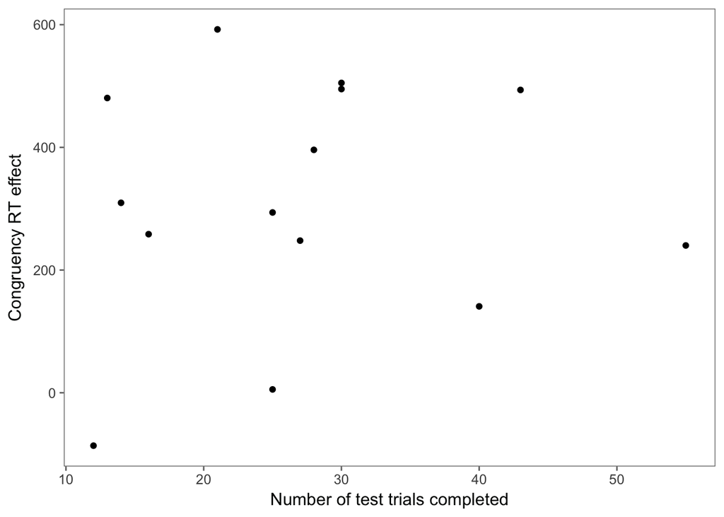

```r
trials_by_RT_effect <- exp.tidy %>%
  group_by(sub, conditionName) %>%
  summarize(trial_count = n(), condition_rt = mean(RT)) %>%
  summarize(trial_count_total = trial_count[conditionName=="mixed"] + trial_count[conditionName=="uniform"], cong_effect = condition_rt[conditionName=="uniform"] - condition_rt[conditionName=="mixed"])

ggplot(trials_by_RT_effect, aes(x=trial_count_total, y=cong_effect)) +
  geom_point() +
  xlab('Number of test trials completed') +
  ylab('Congruency RT effect') +
  theme_few()
```

```r
# Were children who compeleted more trials likely to show a congruency RT effect?
trials_by_RT_cong = cor.test(trials_by_RT_effect$trial_count_total, trials_by_RT_effect$cong_effect)
```